# Experiment 2: Analysis

Making Predictions When Causal Models Change – The Role of Confounding

This script reproduces all results reported for Experiment 2 (Section 4.2 and the Participants section 4.1.1) and Figure 8 of the manuscript. Data: `data/exp2_data.csv` (see `CODEBOOK.md`). Figure output: `figures/`.

# Setup

```r
library(tidyverse)  # data wrangling (dplyr, tidyr) and ggplot2
library(afex)       # aov_car()
library(emmeans)    # estimated marginal means and contrasts
library(binom)      # Wilson CIs for the cluster proportions
library(Hmisc)      # mean_cl_boot() used in stat_summary()
library(ggpubr)     # ggarrange()
library(showtext)   # font rendering

# Fonts: Google fonts are downloaded at run time. Without an internet
# connection the figure falls back to the default sans font.
fonts_ok <- tryCatch({
  font_add_google("Outfit", "title_font")
  font_add_google("Cabin", "body_font")
  TRUE
}, error = function(e) FALSE)
title_font <- if (fonts_ok) "title_font" else "sans"
body_font  <- if (fonts_ok) "body_font"  else "sans"
showtext_auto()
showtext_opts(dpi = 300)

dir.create("figures", showWarnings = FALSE)
```

# Data and exclusions

As pre-registered, participants who needed more than three rounds of the comprehension test (`instr_tests > 3`) were excluded. The device and attention confirmations are applied as in Experiments 1 and 3 (all participants confirmed both).

```r
tdata_raw <- read.csv("data/exp2_data.csv")

# rounds of the comprehension test needed, by condition
table(tdata_raw$causation_type, tdata_raw$instr_tests)
```

```
              1  2  3  4  7  9
  generative 22 14  4  1  0  1
  preventive 33  6  1  2  1  1
```

```r
tdata <- subset(tdata_raw,
                desktop_conf == "1: I confirm" &
                attent_conf  == "1: I will take it seriously" &
                instr_tests  <= 3)

cat("Recruited:", nrow(tdata_raw),
    "| Excluded:", nrow(tdata_raw) - nrow(tdata),
    "| Final N:", nrow(tdata), "\n")
```

```
Recruited: 86 | Excluded: 6 | Final N: 80
```

```r
# n per condition
table(tdata$causation_type)
```

```
generative preventive
        40         40
```

## Demographics

```r
tdata %>%
  summarise(M_age = mean(age), SD_age = sd(age),
            min_age = min(age), max_age = max(age))
```

```
   M_age   SD_age min_age max_age
1 41.325 12.92018      20      69
```

# Normative values

Normative values of P(e|c) for the models in Figure 6: Equation 4 (generative confounding link) and Equation A3 (preventive confounding link).

```r
# Equation 4: generative confounding link A -> C
p_ec_cccf <- function(w_ce, w_ae, w_ac, b_a, b_c) {
  numerator   <- w_ac * b_a + b_c * b_a - w_ac * b_c * b_a
  denominator <- w_ac * b_a + b_c - w_ac * b_c * b_a
  w_ce + (1 - w_ce) * w_ae * (numerator / denominator)
}

# Equation A3: preventive confounding link A -> C
# (b_c cancels out of P(a|c), Equation A1)
p_ec_prev <- function(w_ce, w_ae, w_ac, b_a) {
  p_a_given_c <- (b_a * (1 - w_ac)) / (1 - b_a * w_ac)
  w_ce + (1 - w_ce) * w_ae * p_a_given_c
}

preds <- data.frame(
  causation_type = c("generative", "generative", "preventive", "preventive"),
  case           = c("wac = 0.1", "wac = 0.9", "wac = 0.1", "wac = 0.9"),
  prediction     = c(
    p_ec_cccf(w_ce = 0.3, w_ae = 0.9, w_ac = 0.1, b_a = 0.2, b_c = 0.2),
    p_ec_cccf(w_ce = 0.3, w_ae = 0.9, w_ac = 0.9, b_a = 0.2, b_c = 0.2),
    p_ec_prev(w_ce = 0.3, w_ae = 0.9, w_ac = 0.1, b_a = 0.2),
    p_ec_prev(w_ce = 0.3, w_ae = 0.9, w_ac = 0.9, b_a = 0.2)
  )
)
preds$causation_type <- factor(preds$causation_type,
                               levels = c("generative", "preventive"))
preds$case <- factor(preds$case, levels = c("wac = 0.1", "wac = 0.9"))
preds
```

```
  causation_type      case prediction
1     generative wac = 0.1  0.4633333
2     generative wac = 0.9  0.6369767
3     preventive wac = 0.1  0.4157143
4     preventive wac = 0.9  0.3153659
```

# Mean ratings

`case_01` is the rating for the model with the weak confounding link (w_ac = 0.1), `case_09` the rating for the model with the strong link (w_ac = 0.9), irrespective of the side on which the model was shown.

```r
tdata_main <- tdata %>%
  select(subj_code, causation_type, side_order, case_01, case_09) %>%
  pivot_longer(cols = c(case_01, case_09),
               names_to = "case", values_to = "rating")

tdata_main$causation_type <- factor(tdata_main$causation_type,
                                    levels = c("generative", "preventive"))
tdata_main$case <- factor(tdata_main$case,
                          levels = c("case_01", "case_09"),
                          labels = c("wac = 0.1", "wac = 0.9"))

tdata_main$rating <- tdata_main$rating * 0.01  # convert to 0-1 scale
```

2 (Condition; between) × 2 (Model; within) ANOVA. The η²p of the interaction is the effect size reported for the interaction contrast.

```r
a1 <- aov_car(rating ~ causation_type * case + Error(subj_code / case),
              tdata_main, anova_table = list(es = "pes"))
a1
```

```
Anova Table (Type 3 tests)

Response: rating
               Effect    df  MSE         F  pes p.value
1      causation_type 1, 78 0.08      1.44 .018    .234
2                case 1, 78 0.02      0.96 .012    .331
3 causation_type:case 1, 78 0.02 15.48 *** .166   <.001
---
Signif. codes:  0 '***' 0.001 '**' 0.01 '*' 0.05 '+' 0.1 ' ' 1
```

Cell means (shown in Figure 8A):

```r
emm <- emmeans(a1, ~ case * causation_type)
emm
```

```
 case      causation_type emmean     SE df lower.CL upper.CL
 wac...0.1 generative      0.359 0.0328 78    0.294    0.425
 wac...0.9 generative      0.479 0.0378 78    0.404    0.555
 wac...0.1 preventive      0.508 0.0328 78    0.443    0.573
 wac...0.9 preventive      0.436 0.0378 78    0.361    0.511

Confidence level used: 0.95
```

Planned directed interaction contrast: ratings increase from weak to strong w_ac in the generative condition and decrease in the preventive condition.

```r
# cell order: (0.1, generative), (0.9, generative), (0.1, preventive), (0.9, preventive)
contrast(emm, list(interaction = c(-1, 1, 1, -1)), side = ">")
```

```
 contrast    estimate     SE df t.ratio p.value
 interaction    0.192 0.0489 78   3.935  0.0001

P values are right-tailed
```

Planned simple contrasts within each condition: ratings for w_ac = 0.9 minus ratings for w_ac = 0.1 (two-sided, as pre-registered).

```r
emm_by_type <- emmeans(a1, ~ case | causation_type)
pairs(emm_by_type, reverse = TRUE, adjust = "none")
```

```
causation_type = generative:
 contrast              estimate     SE df t.ratio p.value
 wac...0.9 - wac...0.1   0.1200 0.0346 78   3.473  0.0008

causation_type = preventive:
 contrast              estimate     SE df t.ratio p.value
 wac...0.9 - wac...0.1  -0.0722 0.0346 78  -2.091  0.0398
```

# Clusters

Participants are clustered by their intra-individual rating difference (`case_09 - case_01`). Differences within ±3 points on the 0–100 rating scale are classified as “no change”.

```r
margin_of_error <- 3  # on the 0-100 rating scale

tdata_clusters <- tdata %>%
  mutate(
    rating_difference = case_09 - case_01,
    cluster = case_when(
      abs(rating_difference) <= margin_of_error ~ "no change",
      rating_difference >  margin_of_error      ~ "increase",
      rating_difference < -margin_of_error      ~ "decrease"
    )
  )

tdata_clusters$causation_type <- factor(tdata_clusters$causation_type,
                                        levels = c("generative", "preventive"))

cluster_summary <- tdata_clusters %>%
  count(causation_type, cluster, name = "n") %>%
  group_by(causation_type) %>%
  mutate(n_total = sum(n),
         p = n / n_total,
         percentage = 100 * p) %>%
  ungroup() %>%
  # Wilson 95% CI for each bar
  bind_cols(
    binom.confint(x = .$n, n = .$n_total, methods = "wilson") %>%
      transmute(ci_low = 100 * lower, ci_high = 100 * upper)
  )

cluster_summary
```

```
# A tibble: 5 × 8
  causation_type cluster       n n_total     p percentage ci_low ci_high
  <fct>          <chr>     <int>   <int> <dbl>      <dbl>  <dbl>   <dbl>
1 generative     increase     12      40 0.3         30    18.1     45.4
2 generative     no change    28      40 0.7         70    54.6     81.9
3 preventive     decrease     13      40 0.325       32.5  20.1     48.0
4 preventive     increase      3      40 0.075        7.5   2.58    19.9
5 preventive     no change    24      40 0.6         60    44.6     73.7
```

## Cluster tests

Distribution of clusters across conditions (Pearson’s χ² test):

```r
cluster_table <- table(tdata_clusters$causation_type,
                       factor(tdata_clusters$cluster,
                              levels = c("decrease", "increase", "no change")))
cluster_table
```

```
             decrease increase no change
  generative        0       12        28
  preventive       13        3        24
```

```r
chisq.test(cluster_table)
```

```
    Pearson's Chi-squared test

data:  cluster_table
X-squared = 18.708, df = 2, p-value = 8.663e-05
```

Distribution of clusters within each condition (χ² goodness-of-fit tests against equal cluster frequencies):

```r
chisq.test(cluster_table["generative", ])
```

```
    Chi-squared test for given probabilities

data:  cluster_table["generative", ]
X-squared = 29.6, df = 2, p-value = 3.736e-07
```

```r
chisq.test(cluster_table["preventive", ])
```

```
    Chi-squared test for given probabilities

data:  cluster_table["preventive", ]
X-squared = 16.55, df = 2, p-value = 0.0002548
```

Among participants who changed their ratings, is the normative cluster larger than the non-normative one? Directed (one-sided) binomial tests against 0.5, restricted to the “increase” and “decrease” clusters.

```r
# generative: "increase" > "decrease"
binom.test(x = cluster_table["generative", "increase"],
           n = cluster_table["generative", "increase"] +
               cluster_table["generative", "decrease"],
           p = 0.5, alternative = "greater")
```

```
    Exact binomial test

data:  cluster_table["generative", "increase"] and cluster_table["generative", "increase"] + cluster_table["generative", "decrease"]
number of successes = 12, number of trials = 12, p-value = 0.0002441
alternative hypothesis: true probability of success is greater than 0.5
95 percent confidence interval:
 0.7790778 1.0000000
sample estimates:
probability of success
                     1
```

```r
# preventive: "decrease" > "increase"
binom.test(x = cluster_table["preventive", "decrease"],
           n = cluster_table["preventive", "decrease"] +
               cluster_table["preventive", "increase"],
           p = 0.5, alternative = "greater")
```

```
    Exact binomial test

data:  cluster_table["preventive", "decrease"] and cluster_table["preventive", "decrease"] + cluster_table["preventive", "increase"]
number of successes = 13, number of trials = 16, p-value = 0.01064
alternative hypothesis: true probability of success is greater than 0.5
95 percent confidence interval:
 0.5834277 1.0000000
sample estimates:
probability of success
                0.8125
```

Normative cluster vs. “no change” cluster. Two-sided binomial tests against 0.5, restricted to these two clusters.

```r
# generative: "increase" vs. "no change"
binom.test(x = cluster_table["generative", "increase"],
           n = cluster_table["generative", "increase"] +
               cluster_table["generative", "no change"],
           p = 0.5)
```

```
    Exact binomial test

data:  cluster_table["generative", "increase"] and cluster_table["generative", "increase"] + cluster_table["generative", "no change"]
number of successes = 12, number of trials = 40, p-value = 0.01659
alternative hypothesis: true probability of success is not equal to 0.5
95 percent confidence interval:
 0.1656272 0.4653163
sample estimates:
probability of success
                   0.3
```

```r
# preventive: "decrease" vs. "no change"
binom.test(x = cluster_table["preventive", "decrease"],
           n = cluster_table["preventive", "decrease"] +
               cluster_table["preventive", "no change"],
           p = 0.5)
```

```
    Exact binomial test

data:  cluster_table["preventive", "decrease"] and cluster_table["preventive", "decrease"] + cluster_table["preventive", "no change"]
number of successes = 13, number of trials = 37, p-value = 0.09887
alternative hypothesis: true probability of success is not equal to 0.5
95 percent confidence interval:
 0.2020998 0.5253887
sample estimates:
probability of success
             0.3513514
```

# Figure 8

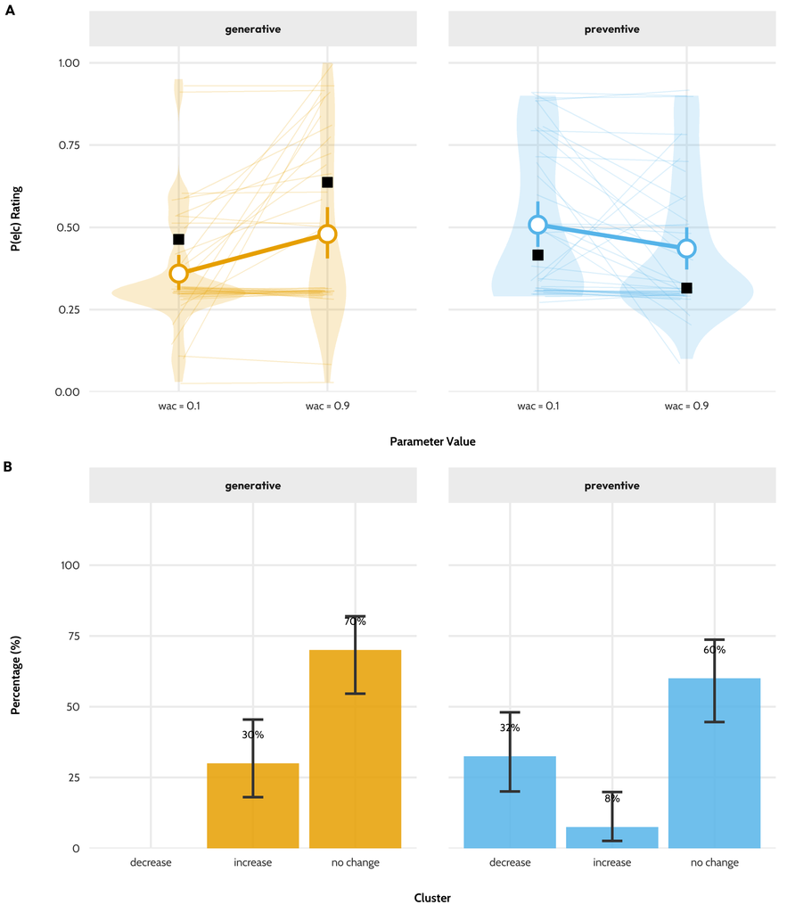

```r
set.seed(1)  # bootstrapped CIs and jittered individual lines

pub_palette <- c("#E69F00", "#56B4E9", "#009E73",
                 "#F0E442", "#0072B2", "#D55E00", "#CC79A7")

# --- ONE knob: all text scales from BASE (identical to Exp 1) ----
BASE <- 14
LAB  <- BASE + 4    # panel letters A / B
TXT  <- BASE - 1    # in-plot percentage labels

theme_pub <- function(base = BASE) {
  theme_minimal(base_size = base) +
    theme(
      text             = element_text(family = body_font),
      strip.background = element_rect(fill = "grey92", color = "grey92"),
      strip.text       = element_text(face = "bold", size = base,
                                      family = title_font,
                                      margin = margin(5, 5, 5, 5)),
      axis.title       = element_text(face = "bold", size = base + 1),
      axis.title.x     = element_text(margin = margin(t = 10), face = "bold"),
      axis.title.y     = element_text(margin = margin(r = 10), face = "bold"),
      axis.text        = element_text(size = base, color = "grey20"),
      panel.grid.minor = element_blank(),
      legend.position  = "none"
    )
}

# --- Panel A: ratings --------------------------------------------
g3 <- ggplot(tdata_main, aes(x = case, y = rating,
                             fill = causation_type, color = causation_type)) +
  facet_wrap(~ causation_type, nrow = 1) +
  geom_line(aes(group = subj_code),
            position = position_jitter(height = 0.02, width = 0.05),
            linewidth = 0.35, alpha = 0.2) +
  geom_violin(alpha = 0.2, color = NA, trim = TRUE) +
  stat_summary(aes(group = 1), fun.data = mean_cl_boot, geom = "errorbar",
               width = 0, linewidth = 1) +
  stat_summary(aes(group = 1), fun = mean, geom = "line", linewidth = 1.3) +
  stat_summary(aes(group = 1), fun = mean, geom = "point", shape = 21,
               size = 4.2, stroke = 1.4, fill = "white") +
  geom_point(data = preds, aes(x = case, y = prediction),
             color = "black", fill = "black", size = 3, shape = 22) +
  scale_y_continuous(limits = c(0, 1.05), breaks = seq(0, 1, 0.25),
                     expand = c(0, 0)) +
  scale_color_manual(values = pub_palette) +
  scale_fill_manual(values = pub_palette) +
  labs(x = "Parameter Value", y = "P(e|c) Rating") +
  theme_pub() +
  theme(panel.spacing = unit(1.4, "lines"))

# --- Panel B: clusters -------------------------------------------
g4 <- ggplot(cluster_summary, aes(x = cluster, y = percentage,
                                  fill = causation_type)) +
  facet_wrap(~ causation_type, nrow = 1) +
  geom_bar(stat = "identity", alpha = 0.85, color = NA) +
  geom_errorbar(aes(ymin = ci_low, ymax = ci_high), width = 0.2,
                linewidth = 0.8, color = "grey20") +
  geom_text(aes(label = paste0(round(percentage, 0), "%")),
            vjust = -3.5, family = body_font, size = TXT / .pt) +
  scale_y_continuous(limits = c(0, 122), breaks = seq(0, 100, 25),
                     expand = c(0, 0)) +
  scale_fill_manual(values = pub_palette) +
  labs(x = "Cluster", y = "Percentage (%)") +
  theme_pub() +
  theme(panel.spacing = unit(1.4, "lines"))

# --- Assemble ----------------------------------------------------
figure8 <- ggarrange(g3, g4,
                     labels = c("A", "B"),
                     font.label = list(size = LAB, color = "black",
                                       family = title_font),
                     ncol = 1, nrow = 2, align = "v")
figure8
```

```r
ggsave("figures/Figure8_Exp2.pdf", figure8,
       width = 6.9, height = 8, units = "in", device = cairo_pdf)
```